# Assessing Pesticide Contamination in Illinois Water Supply and the Impact of Agricultural Practices

Carson Edwards

1. Load in libraries

```r
library(purrr)
library(readr)
library(corrplot)
library(forecast)
library(tidyr)
library(randomForest)
library(xgboost)
library(changepoint)
library(urbnmapr)
library(ggplot2)
library(dplyr)
library(data.table)
```

```
                                            TRI PROGRAM DATASET ANALYSIS SECTION
```

2. Load and format TRI program data

```r
folder_path <- "C:/Users/carso/Downloads/il_chemicals/"
file_list <- list.files(path = folder_path, pattern = "\\d{4}_il\\.csv$", full.names = TRUE)

combined_data <- map_df(file_list, ~ read_csv(.x, col_types = cols(.default = "c")))

# Clean up column names
cleaned_colnames <- colnames(combined_data) %>%
  gsub("^\\d+\\.\\s*", "", .) %>%
  gsub("\\s+", "_", .) %>%
  tolower()
colnames(combined_data) <- cleaned_colnames

# Mutate total releases to numeric, convert yes/no to logical, and as numeric
combined_data <- combined_data %>%
  mutate(
    total_releases = as.numeric(total_releases),
    across(where(~ is.character(.) & all(. %in% c("YES", "NO"))), ~ . == "YES"),
    across(where(is.logical), as.numeric)
  )

# Get sums of county, chemical, and year combinations
chemical_by_county <- combined_data %>%
  group_by(county, chemical, year) %>%
  summarise(total_releases = sum(total_releases, na.rm = TRUE))
# Load in our county map data
illinois_counties <- get_urbn_map("counties", sf = FALSE) %>%
  filter(state_abbv == "IL")

head(combined_data)
```

| year | trifd | frs_id | facility_name | street_address | city | county | st | zip | bia | tribe | latitude | longitude | horizontal_datum | parent_co_name | parent_co_db_num | standard_parent_co_name | foreign_parent_co_name | foreign_parent_co_db_num | standard_foreign_parent_co_name | federal_facility | industry_sector_code | industry_sector | primary_sic | sic_2 | sic_3 | sic_4 | sic_5 | sic_6 | primary_naics | … |
| --- | --- | --- | --- | --- | --- | --- | --- | --- | --- | --- | --- | --- | --- | --- | --- | --- | --- | --- | --- | --- | --- | --- | --- | --- | --- | --- | --- | --- | --- | --- |
| 2001 | 60039TCNDSRT31X | 110006165746 | TC INDUSTRIES INC | 3703 S RT 31 | CRYSTAL LAKE | MCHENRY | IL | 60012 | NA | NA | 42.275281 | -88.291039 | NAD83 | NA | NA | NA | NA | NA | NA | 0 | 332 | Fabricated Metals | 3398 | NA | NA | NA | NA | NA | 332811 | … |
| 2001 | 62201THYLPMONSA | 110000438884 | AFTON CHEMICAL CORP | 501 MONSANTO AVE | SAUGET | ST. CLAIR | IL | 62201 | NA | NA | 38.601444 | -90.167633 | NAD83 | NEWMARKET CORP | 003132222 | NEWMARKET CORP | NA | NA | NA | 0 | 325 | Chemicals | 2869 | NA | NA | NA | NA | NA | 325199 | … |
| 2001 | 60628SHRWN11541 | 110008457295 | SHERWIN-WILLIAMS CO | 11700 S COTTAGE GROVE | CHICAGO | COOK | IL | 60628 | NA | NA | 41.681245 | -87.608389 | NAD83 | THE SHERWIN-WILLIAMS CO | 004206397 | THE SHERWIN-WILLIAMS CO | NA | NA | NA | 0 | 325 | Chemicals | 2851 | NA | NA | NA | NA | NA | 325510 | … |
| 2001 | 60120HNKLD1345G | 110035808837 | HENKEL US OPERATIONS CORP. | 1345 GASKET DR | ELGIN | COOK | IL | 60120 | NA | NA | 41.996500 | -88.239270 | NAD83 | HENKEL US OPERATIONS CORP | NA | NA | NA | NA | NA | 0 | 325 | Chemicals | 2891 | NA | NA | NA | NA | NA | 325520 | … |
| 2001 | 61132BRBRC1354C | 110066942474 | SCHNEIDER-ELECTRIC LLC | 1354 CLIFFORD AVE | LOVES PARK | WINNEBAGO | IL | 61111 | NA | NA | 42.319030 | -89.041220 | NAD83 | SCHNEIDER ELECTRIC USA INC | 001288364 | SCHNEIDER ELECTRIC USA INC | NA | NA | NA | 0 | 336 | Transportation Equipment | 3519 | 3728 | 3822 | 3823 | NA | NA | 336399 | … |
| 2001 | 60901HNKLCSKENS | 110043972207 | KENSING LLC | 2525 S KENSINGTON AVE | KANKAKEE | KANKAKEE | IL | 60901 | NA | NA | 41.085542 | -87.880542 | NAD83 | KENSING HOLDINGS LLC | 118985922 | KENSING HOLDINGS LLC | NA | NA | NA | 0 | 325 | Chemicals | 2821 | 2869 | 2843 | 2833 | NA | NA | 325211 | … |

```r
head(chemical_by_county)
```

| county | chemical | year | total_releases |
| --- | --- | --- | --- |
| ADAMS | 2-Phenylphenol | 2015 | 0.0 |
| ADAMS | 2-Phenylphenol | 2016 | 0.0 |
| ADAMS | Aluminum oxide (fibrous forms) | 2004 | 72939.0 |
| ADAMS | Aluminum oxide (fibrous forms) | 2005 | 72967.0 |
| ADAMS | Aluminum oxide (fibrous forms) | 2006 | 98633.0 |
| ADAMS | Aluminum oxide (fibrous forms) | 2007 | 86443.2 |

3. Correlation modeling

```r
# Selecting our numeric data, we have already converted true/false to 1/0
numeric_data <- combined_data %>%
  select_if(is.numeric)
correlation_matrix <- cor(numeric_data, use = "complete.obs")

correlation_matrix
```

```
                         federal_facility elemental_metal_included clean_air_act_chemical        metal   carcinogen           pbt          pfas total_releases
federal_facility             1.0000000000             -0.004400299           2.756273e-03  0.010069210  0.033442971  4.546254e-02 -0.0004614205  -0.0033693730
elemental_metal_included    -0.0044002990              1.000000000           4.703926e-02  0.141343327 -0.029909940  9.252047e-02 -0.0011087767   0.0037716602
clean_air_act_chemical       0.0027562734              0.047039260           1.000000e+00 -0.048969995  0.177330690  6.052090e-07 -0.0115923471  -0.0419258675
metal                        0.0100692104              0.141343327          -4.897000e-02  1.000000000  0.065808622  3.302266e-01 -0.0074324551   0.0112175256
carcinogen                   0.0334429714             -0.029909940           1.773307e-01  0.065808622  1.000000000  2.413876e-01  0.0023449760  -0.0397761881
pbt                          0.0454625433              0.092520466           6.052090e-07  0.330226619  0.241387601  1.000000e+00 -0.0037715181  -0.0328457127
pfas                        -0.0004614205             -0.001108777          -1.159235e-02 -0.007432455  0.002344976 -3.771518e-03  1.0000000000  -0.0008549982
total_releases              -0.0033693730              0.003771660          -4.192587e-02  0.011217526 -0.039776188 -3.284571e-02 -0.0008549982   1.0000000000
```

[figure not shown]

```r
colnames(correlation_matrix) <- gsub("_", " ", colnames(correlation_matrix))
rownames(correlation_matrix) <- gsub("_", " ", rownames(correlation_matrix))

# Paste into console to see a readable plot in plot window
corrplot(correlation_matrix,
         method = "color",
         tl.cex = 1.5,
         tl.col = "black",
         addCoef.col = "black")
```

4. Random forest model for feature importance

```r
# Only selecting fields of interest
model_data <- combined_data %>%
  select(total_releases, year, federal_facility, elemental_metal_included, clean_air_act_chemical, metal, carcinogen, pbt, pfas)

set.seed(123)
rf_model <- randomForest(total_releases ~ ., data = model_data, importance = TRUE, ntree = 500)

print(rf_model)
```

```
Call:
 randomForest(formula = total_releases ~ ., data = model_data,      importance = TRUE, ntree = 500)
               Type of random forest: regression
                     Number of trees: 500
No. of variables tried at each split: 2

          Mean of squared residuals: 73827638192
                    % Var explained: 0.48
```

```r
importance(rf_model)
```

```
                           %IncMSE IncNodePurity
year                      7.674713  2.830637e+12
federal_facility          5.625889  3.394976e+10
elemental_metal_included  9.285051  7.679550e+11
clean_air_act_chemical   36.188221  1.065696e+13
metal                    26.927291  4.120005e+12
carcinogen               32.283238  7.966650e+12
pbt                      30.601349  5.337563e+12
pfas                      6.646834  2.565066e+09
```

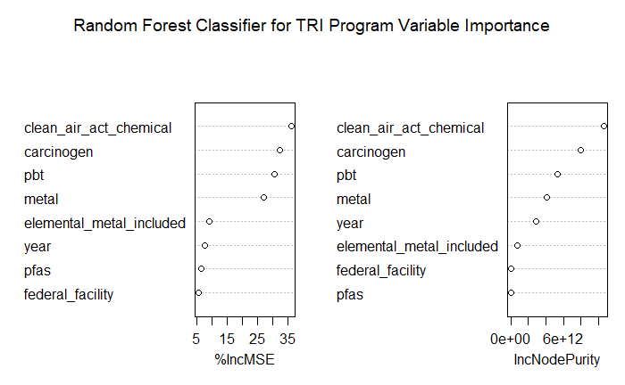

```r
varImpPlot(rf_model,
           main = "Random Forest Classifier for TRI Program Variable Importance")
```

5. Change point analysis for TRI program data

```r
get_change_points <- function(df) {
  df$year <- as.numeric(df$year)
  df <- df[order(df$year), ]
  if (any(is.na(df$total_releases)) || !is.numeric(df$total_releases)) {
    return(NULL)
  }

  releases <- as.numeric(df$total_releases)
  max_Q <- length(releases) - 1

  # The max change points to search for. Taking either length of county chemical combinations or total number of rows. Want less change points rather than more
  Q <- min(3, max_Q)
  if (Q < 1) {
    return(NULL)
  }

  # Was getting too many warnings with the output
  suppressWarnings({
    cpt <- cpt.mean(releases, method = "BinSeg", penalty = "BIC", Q = Q)
  })

  return(cpts(cpt))
}

change_points <- list()

# Only want combinations with at least 3 reported years
valid_data <- chemical_by_county %>%
  group_by(county, chemical) %>%
  filter(n() >= 3) %>%
  ungroup()

# Need unique pairs
unique_combinations <- unique(valid_data[, c("county", "chemical")])

# For each unique combination of county and chemical, take the subset of data and run get change points function
for (i in 1:nrow(unique_combinations)) {
  county1 <- unique_combinations$county[i]
  chemical1 <- unique_combinations$chemical[i]
  subset_data <- subset(valid_data, county == county1 & chemical == chemical1)

  result <- get_change_points(subset_data)

  if (!is.null(result)) {
    change_points[[paste(county1, chemical1, sep = "_")]] <- result
  } else {
    change_points[[paste(county1, chemical1, sep = "_")]] <- "No valid data or change points"
  }
}
```

6. Functions for plotting change points and getting year counts

```r
plot_change_points <- function(df, change_points) {
  df$year <- as.numeric(df$year)

  # Order by year
  df <- df[order(df$year), ]

  # Create change point plot of total releases
  change_point_plot <- ggplot(df, aes(x = year, y = total_releases)) +
    geom_line() +
    geom_point() +
    labs(title = paste(df$county[1], df$chemical[1], "Change Point Detection"),
         x = "Year", y = "Total Releases") +
    theme_minimal()

  # Plotting change points using a vertical red line
  if (!is.null(change_points) && length(change_points) > 0) {
    change_point_plot <- change_point_plot + geom_vline(xintercept = df$year[change_points], color = "red", linetype = "dashed")
  }
  print(change_point_plot)
}

analyze_change_points <- function(chemical_name, chemical_by_county, change_points) {
  unique_counties <- unique(chemical_by_county$county[chemical_by_county$chemical == chemical_name])
  change_point_years <- c()

  # For each county chemical combination, get the change point counts
  for (county1 in unique_counties) {
    subset_data <- subset(chemical_by_county, county == county1 & chemical == chemical_name)
    change_point_result <- change_points[[paste(county1, chemical_name, sep = "_")]]

    if (!is.null(change_point_result)) {
      plot_change_points(subset_data, change_point_result)
      change_point_years <- c(change_point_years, change_point_result)  # Collect change point years
    }
  }

  change_point_year_counts <- table(change_point_years)

  # Plot the totals
  barplot(change_point_year_counts,
          main = paste("Frequency of Change Point Years for", chemical_name),
          xlab = "Year",
          ylab = "Frequency",
          col = "skyblue",
          las = 2,
          names.arg = as.character(as.numeric(names(change_point_year_counts)) + 2000)) # Have years display correctly

}
```

Ammonia example

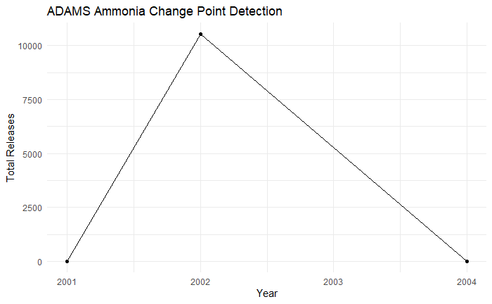

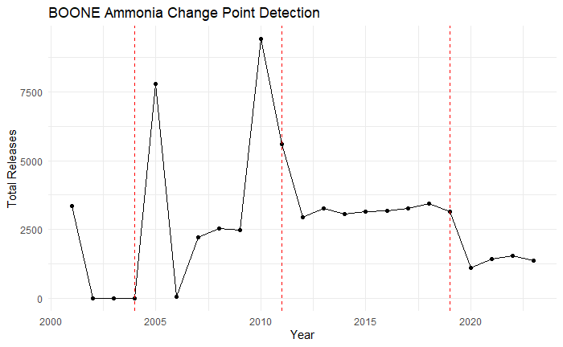

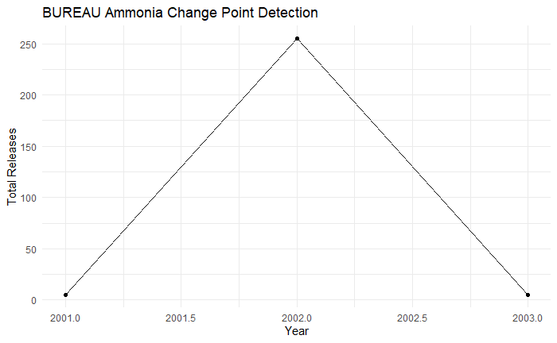

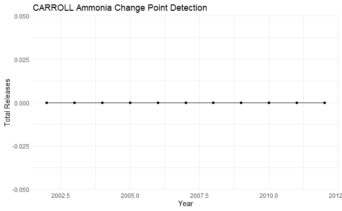

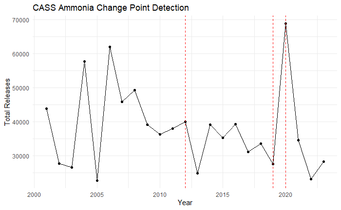

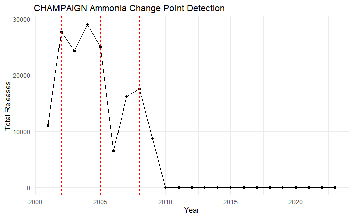

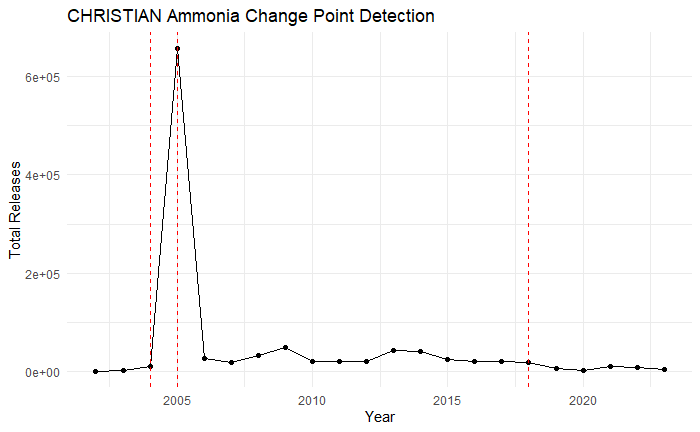

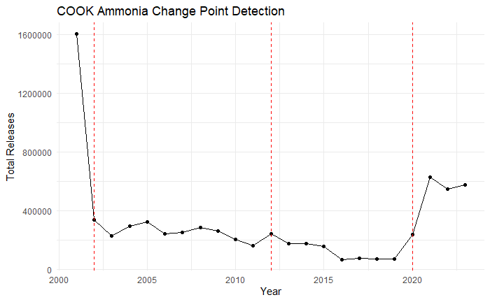

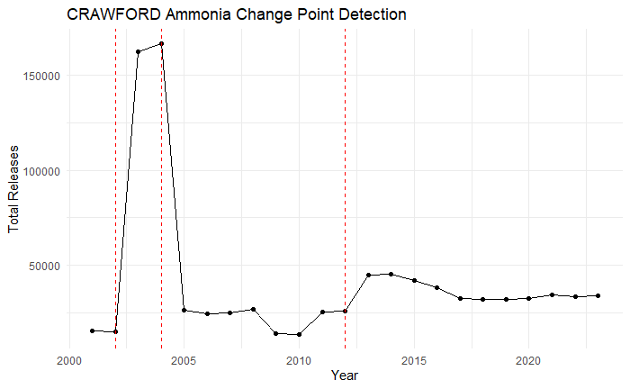

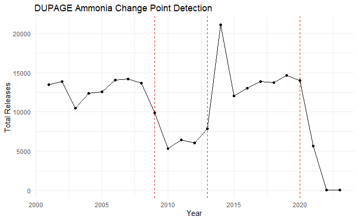

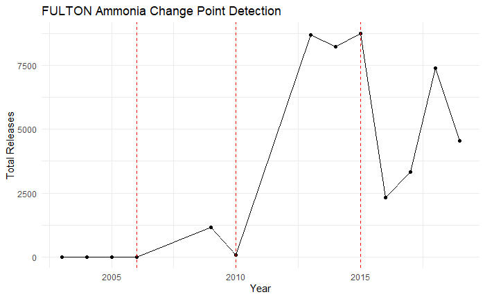

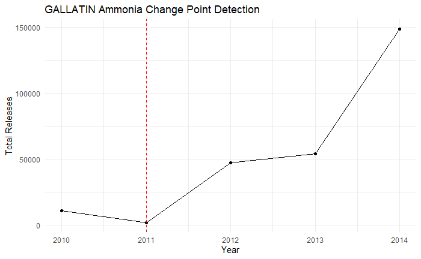

[38 more figures not shown]

```r
analyze_change_points("Ammonia", chemical_by_county, change_points)
```

Benzene example

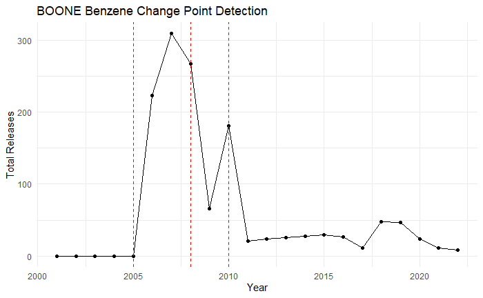

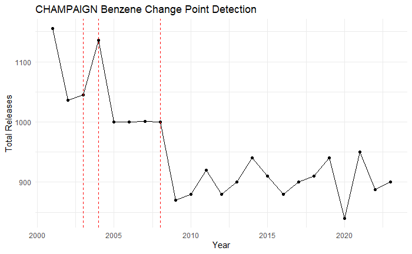

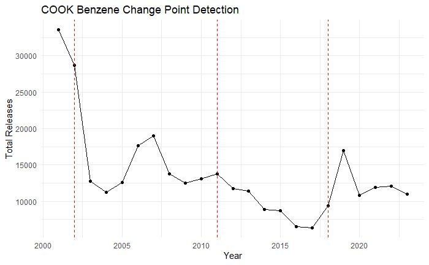

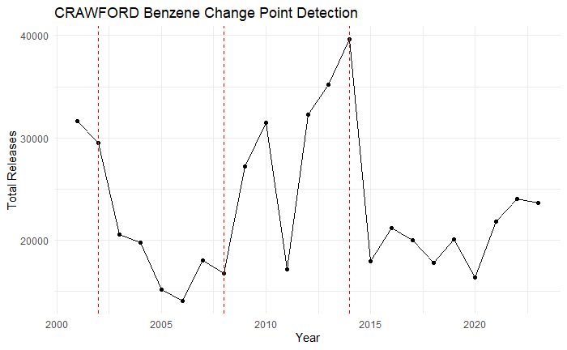

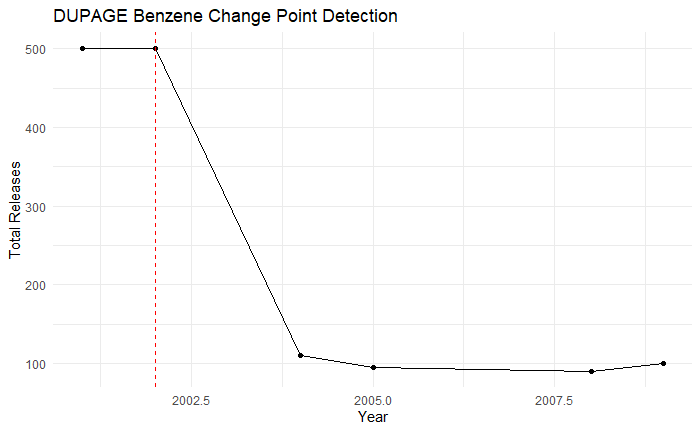

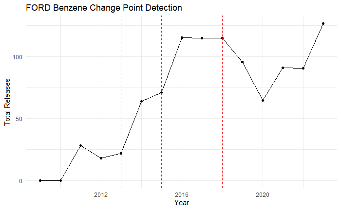

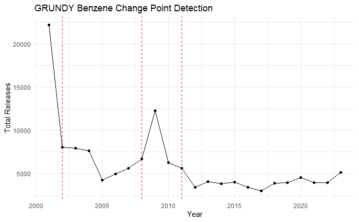

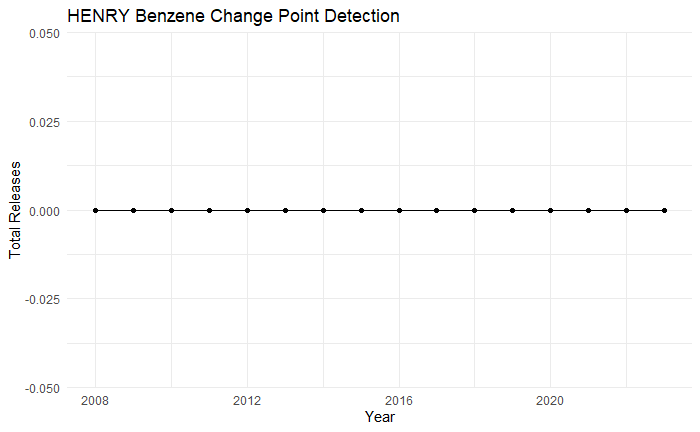

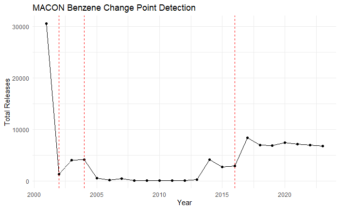

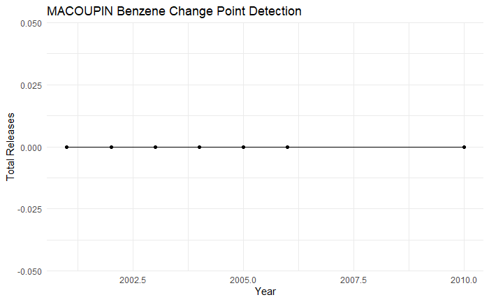

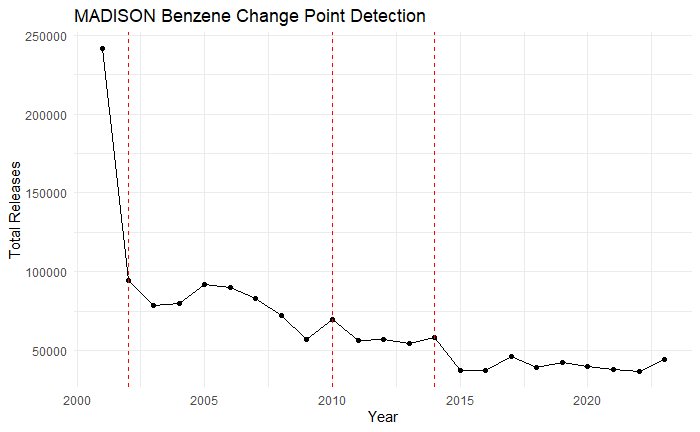

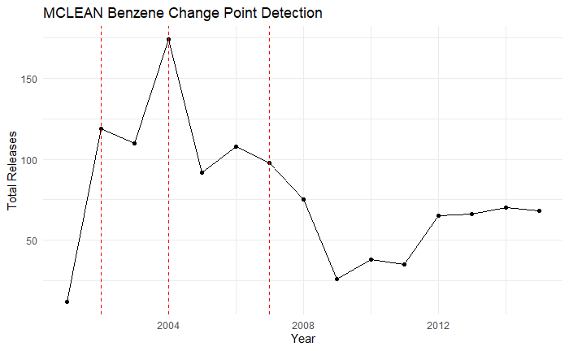

[10 more figures not shown]

```r
analyze_change_points("Benzene", chemical_by_county, change_points)
```

Change point detection by year

```r
change_points <- list()

# Group by year and chemical this time
valid_data <- chemical_by_county %>%
  group_by(year, chemical) %>%
  summarise(total_releases = sum(total_releases, na.rm = TRUE)) %>%
  filter(n() >= 3) %>%
  ungroup()
# Only unique chemicals since no counties
unique_chemicals <- unique(valid_data$chemical)

# For each unique chemical, take the subset of data and run get change points function
for (i in 1:length(unique_chemicals)) {
  chemical1 <- unique_chemicals[i]
  subset_data <- subset(valid_data, chemical == chemical1)

  result <- get_change_points(subset_data)

  if (!is.null(result)) {
    change_points[[chemical1]] <- result
  } else {
    change_points[[chemical1]] <- "No valid data or change points"
  }
}

plot_change_points <- function(df, change_points) {
  df$year <- as.numeric(df$year)

  # Order by year
  df <- df[order(df$year), ]

  # Create change point plot of total releases
  change_point_plot <- ggplot(df, aes(x = year, y = total_releases)) +
    geom_line() +
    geom_point() +
    labs(title = paste(df$chemical[1], "Change Point Detection"),
         x = "Year", y = "Total Releases") +
    theme_minimal()

  # Plotting change points using a vertical red line
  if (!is.null(change_points) && length(change_points) > 0) {
    change_point_plot <- change_point_plot + geom_vline(xintercept = df$year[change_points], color = "red", linetype = "dashed")
  }
  print(change_point_plot)
}

analyze_change_points <- function(chemical_name, chemical_by_county, change_points) {
  subset_data <- subset(chemical_by_county, chemical == chemical_name)  # Only chemical for this subset
  change_point_result <- change_points[[chemical_name]]

  if (!is.null(change_point_result)) {
    plot_change_points(subset_data, change_point_result)
    change_point_years <- change_point_result  # Collect change point years
  } else {
    change_point_years <- c()
  }
}
```

Ammonia change points statewide

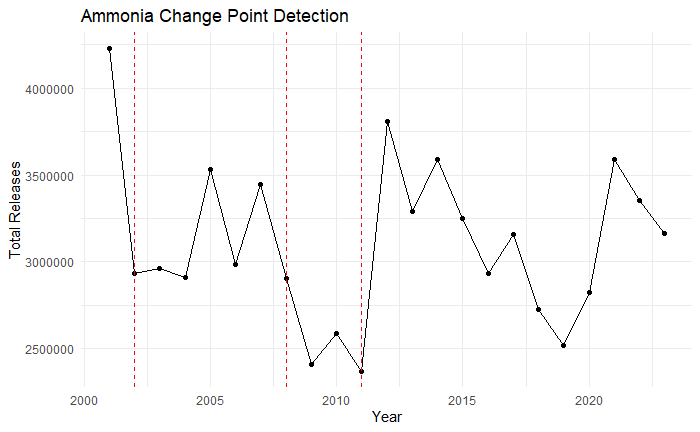

```r
analyze_change_points("Ammonia", valid_data, change_points)
```

Benzene change points statewide

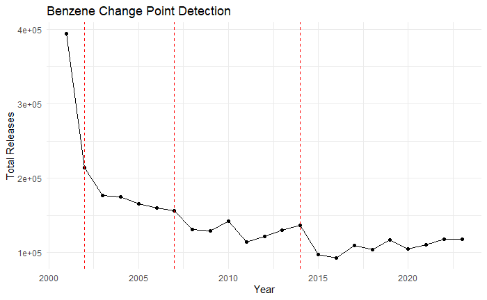

```r
analyze_change_points("Benzene", valid_data, change_points)
```

Atrazine change points statewide

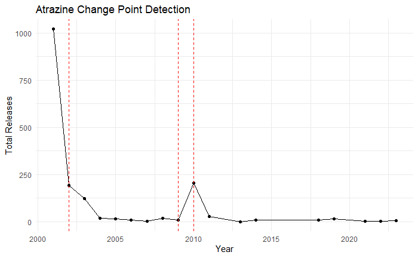

```r
analyze_change_points("Atrazine", valid_data, change_points)
```

2,4-D change points statewide

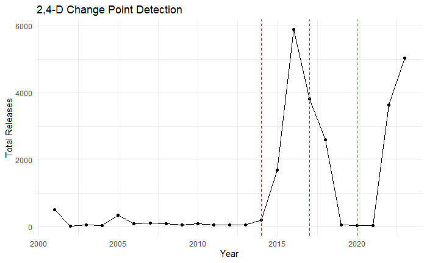

```r
analyze_change_points("2,4-D", valid_data, change_points)
```

7. Geospatial analysis for TRI program data

Average yearly increase function

```r
plot_avg_yearly_increase <- function(chemical_name, chemical_by_county, illinois_counties) {

  # Filter by chemical of interest, group by county, arrange by year, calculate yearly change, take the mean and drop groups
  avg_increase_data <- chemical_by_county %>%
    filter(chemical == chemical_name) %>%
    group_by(county) %>%
    arrange(year) %>%
    mutate(yearly_change = total_releases - lag(total_releases)) %>%
    summarize(avg_yearly_increase = mean(yearly_change, na.rm = TRUE), .groups = "drop") %>%
    rename(county_name = county)

  # Convert county names to regular format ex "Jo Daviess County"
  avg_increase_data$county_name <- paste(tools::toTitleCase(tolower(avg_increase_data$county_name)), "County")

  # Set up counties data with average increase data by county name
  spatial_data <- left_join(illinois_counties, avg_increase_data, by = "county_name")

  # Plot using Albers projection to minimize warping, remove axis labels, and apply nice color scheme
  plot <- ggplot() +
    geom_polygon(data = spatial_data,
                 mapping = aes(x = long, y = lat, group = group, fill = avg_yearly_increase),
                 color = "#ffffff", size = 0.25) +
    coord_map(projection = "albers", lat0 = 39, lat1 = 45) +
    scale_fill_gradient2(midpoint = 0, low = "blue", mid = "lightblue", high = "orange",
                     na.value = "grey", name = "Average Yearly Increase in lbs") +
    labs(title = paste("Average Yearly Increase in Total Releases of", chemical_name)) +
    theme_minimal() +
    theme(axis.title = element_blank(),
          axis.text = element_blank(),
          axis.ticks = element_blank())

  print(plot)
}
```